# Part II - (Ford GoBike System Data)

## Investigation Overview

> The goal of the project was to investigate the Ford Go Bike dataset and communicate data findings using data visualization techniques. The project was made to showcase the value of univariate, bivariate and multivariate visualizations.

## Dataset Overview

> The dataset has 183412 rows and 16 columns. The dataset generally shows the duration of the trip, the start and end station id's & longitude and latitude. The type of user and the gender are also noted. We have some quantitative data, the ID's should all be treated as nominal data (qualitative data). The longitude and latitude can be treated as numeric data for the purpose for any calculations.

```python
# import all packages and set plots to be embedded inline
import numpy as np
import pandas as pd
import matplotlib.pyplot as plt
import seaborn as sb

%matplotlib inline

# suppress warnings from final output
import warnings
warnings.simplefilter("ignore")
```

```python
df_v2 = pd.read_csv('final_ford_data.csv')
```

## What Gender takes the most bike trips?

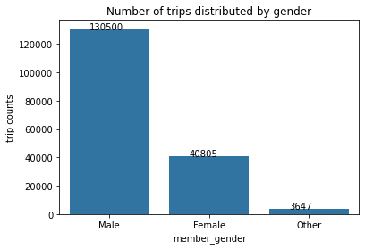

```python
base_color = sb.color_palette()[0];
ax = sb.countplot(x = df_v2['member_gender'], order=df_v2['member_gender'].value_counts().index, color=base_color);

for g, label in zip(ax.patches, df_v2['member_gender'].value_counts()):
    ax.annotate(label, (g.get_x()+0.20, g.get_height()));

plt.title('Number of trips distributed by gender');
plt.ylabel('trip counts');
```

## What age category takes the most bike trips?

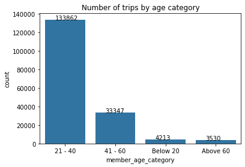

```python
base_color = sb.color_palette()[0];
ax = sb.countplot(x = df_v2['member_age_category'], order=df_v2['member_age_category'].value_counts().index, color=base_color);

for g, label in zip(ax.patches, df_v2['member_age_category'].value_counts()):
    ax.annotate(label, (g.get_x()+0.20, g.get_height()));

plt.title('Number of trips by age category');
```

## Which user type takes more trips?

> Subscribers take far more trips than customers. This is a good insight, assuming that subscribers have a membership with the company.

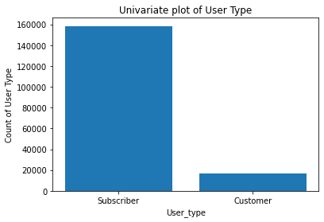

```python
plt.bar(x=df.user_type.value_counts().keys(), height=df.user_type.value_counts());
plt.xlabel('User_type')
plt.ylabel('Count of User Type')
plt.title('Univariate plot of User Type');
```

> **Generate Slideshow**: Once you're ready to generate your slideshow, use the `jupyter nbconvert` command to generate the HTML slide show. . From the terminal or command line, use the following expression.

```python
!jupyter nbconvert Part_II_slide_deck_template.ipynb --to slides --post serve --no-input --no-prompt
```

```
^C
```